# Prob 4 CP 3: Suas análises

Thierry Barros

July 16, 2018

```r
library(here)
library(readr)
library(tidyverse)
library(resample)
library(timeDate)
library(lubridate)
github = read_csv("github.csv",
                  col_types = cols(
                        file_extension = col_character(),
                        month_day = col_character(),
                        the_month = col_character(),
                        the_year = col_character(),
                        users = col_integer())
  )
```

Os dados a serem utilizados são dados da atividade global do github. As linguagens que serão analisadas serão linguagem c e python. Duas linguagens bem famosas entre os programadores. Foram coletados quase 500 observações de cada uma das linguagens.

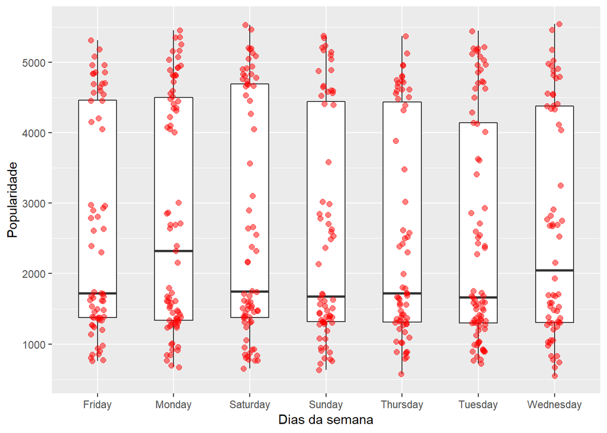

```r
library(lubridate)
#Omitindo os dados nulos(Mas não tinha nenhum)
github = na.omit(github)

#Classificando as observações por dia da semana
github$date = paste(github$month_day, github$the_month, github$the_year, sep="-")
github$day = format.Date(as.Date(github$date), "%A")

linguagens= github[github$file_extension == c("py","c"),]

#Classificando as observações por dia da semana
github$date = paste(github$month_day, github$the_month, github$the_year, sep="-")
github$day = format.Date(as.Date(github$date), "%A")

linguagens %>%
    ggplot(aes(x = day, y = users)) +
    geom_boxplot(width = .5, outlier.color = NA) +
    geom_jitter(width = .1, size = 2, alpha = .5, color = "red")+ xlab("Dias da semana") +
  ylab("Popularidade")
```

Como podemos ver acima os dados não possuiam nenhum problema com valores faltantes e o desvio padrão foi relativamente alto, gerando os boxplotos por dia da semana não tem nenhum outlier nos dados, então não foi preciso fazer nenhum tratamento dos dados.O único tratamento foi descobrir o dia da semana relativo a data mostrada nos dados.